# Storm Data Analysis

# Major weather events impact in the United States

## Synopsis

This report aim to answer below two questions about the impact of severe weather events in the United States.

1. which types of events (EVTYPE) are most harmful with respect to population health
2. which types of events have the greatest economic consequences

The data set provided by Coursera is used for analysis, that is an extract from the U.S. National Oceanic and Atmospheric Administration's (NOAA) storm Database.

The data from 2000 to 2011 are used for analysis in the report. The harm to population health is measured in terms of number of fatalities and injuries. The impact on economy is measured by damage to crops and property.

Based on the analysis, following events are top ones that impact the population health: - tornado - excessive heat - lightning - hurriane - TSTM(Thunderstorm) Wind - Thunderstorm

Following events have caused highest impact on economy: - hurricane - storm surge - tornado - hail - flood - flash flood

This report could be of interest to government or municipal managers who might be responsible for preparing for severe weather events and will need to prioritize resources for different types of events.

This report was made as an assignment for the [Reproducible Research](https://www.coursera.org/course/repdata) Coursera course.

** Following steps are applied in the report: - Load data - Filter out used variables - Filter out data for the period with enough records - Optimize Event Type element value - Calculate damage to economy based on property damage and crops damage - Calculate impact on popular health in terms of fatalities and injuries

## Load Data

### Preparation

Following libraries are required:

- dplyr
- lubridate
- xtable
- knitr

### Reading the data

The data source is the compressed file from the Coursera course site: [Storm data](https://d396qusza40orc.cloudfront.net/repdata%2Fdata%2FStormData.csv.bz2). The data set is downloaded and stored under the work directory, so the download is not tried.

```r
#url <- "https://d396qusza40orc.cloudfront.net/repdata%2Fdata%2FStormData.csv.bz2"
#destfile <- "repdata-data-StormData.csv.bz2"
#if(!file.exists(destfile)){
#   download.file(url, destfile)
#}
#stormData <- read.csv(bzfile("repdata-data-StormData.csv.bz2"))
#unlink(destfile)

#or
#unzip("repdata-data-StormData.csv.bz2")
Sys.setlocale(category="LC_ALL", locale="us")
```

```
## [1] "LC_COLLATE=English_United States.1252;LC_CTYPE=English_United States.1252;LC_MONETARY=English_United States.1252;LC_NUMERIC=C;LC_TIME=English_United States.1252"
```

```r
stormData <- read.csv("repdata_data_StormData.csv")

dim(stormData)
```

```
## [1] 902297     37
```

The result stormData contains 902297*37, covering data from 1950 to 2011. Next step is to filter out data for the period with enough records.

## Data Processing

### Filter out used variables

```r
names(stormData)
```

```
##  [1] "STATE__"    "BGN_DATE"   "BGN_TIME"   "TIME_ZONE"  "COUNTY"
##  [6] "COUNTYNAME" "STATE"      "EVTYPE"     "BGN_RANGE"  "BGN_AZI"
## [11] "BGN_LOCATI" "END_DATE"   "END_TIME"   "COUNTY_END" "COUNTYENDN"
## [16] "END_RANGE"  "END_AZI"    "END_LOCATI" "LENGTH"     "WIDTH"
## [21] "F"          "MAG"        "FATALITIES" "INJURIES"   "PROPDMG"
## [26] "PROPDMGEXP" "CROPDMG"    "CROPDMGEXP" "WFO"        "STATEOFFIC"
## [31] "ZONENAMES"  "LATITUDE"   "LONGITUDE"  "LATITUDE_E" "LONGITUDE_"
## [36] "REMARKS"    "REFNUM"
```

```r
filterData <- subset(stormData[,c(2, 8, 23, 24, 25, 26, 27, 28)])
```

In order to get the answer to the questions about the impact of event types to population health and economy, following variables are fethed out from the data set:

- BGN_DATE: Begin date of event. The included year is used to check and select the period with enough records.
- EVTYPE: Event Type. The values of most are defined manually with different name. Optimization is applied to classify similar items with same name.
- FATALITIES: Number of fatalities.
- INJURIES: Number of injuries.
- PROPDMG: Damage to property, with unit identified in "PROPDMGEXP".
- PROPDMGEXP: Unit of PROPDMG. It has values as B,M,K,H,etc.
- CROPDMG: Damage to crops, with unit identified in "CROPDMGEXP".
- CROPDMGEXP: Unit of CROPDMGEXP. It has values as B,M,K,H,etc.

### Filter out data based on time period

```r
Sys.setlocale(category="LC_ALL", locale="us")
```

```
## [1] "LC_COLLATE=English_United States.1252;LC_CTYPE=English_United States.1252;LC_MONETARY=English_United States.1252;LC_NUMERIC=C;LC_TIME=English_United States.1252"
```

```r
filterData_y <- subset(filterData, nchar(BGN_DATE)==17)

library(lubridate)
filterData_y$year <- year(as.Date(filterData_y$BGN_DATE, format = "%m/%d/%Y"))
table(filterData_y$year)
```

```
##
##  1950  1951  1952  1953  1954  1955  1956  1957  1958  1959  1960  1961  1962
##   150   178   213   315   447   946  1074  1537  1507  1319  1324  1356  1805
##  1963  1964  1965  1966  1967  1968  1969  1970  1971  1972  1973  1974  1975
##  1433  1510  1877  1687  1840  2353  1935  2255  2232  1559  2985  3559  3431
##  1976  1977  1978  1979  1980  1981  1982  1983  1984  1985  1986  1987  1988
##  3204  2469  2599  2922  3641  3324  5091  5151  4554  5136  6188  5157  4571
##  1989  1990  1991  1992  1993  1994  1995  1996  1997  1998  1999  2000  2001
##  5991  7560  8167  9289  7873 14558 17716 21814 19250 26176 19197 23700 22177
##  2002  2003  2004  2005  2006  2007  2008  2009  2010  2011
## 23432 23411 26179 25528 29320 27840 34119 30133 32095 43048
```

```r
dataF2000 <- subset(filterData_y, year>=2000)
dim(dataF2000)
```

```
## [1] 340982      9
```

According to the filtered out year, the data of old period before 1995 have less records. The data from 2000 to 2011 are selected for further data analysis, because total more than 340K (340982) records could be enough.

### Event Type Optimization

The NOAA storm database code book reports 48 event type. The event types in the data data has hundreds of types. The event type value is optimized to apply same name for similar events.

```r
dataFxxxx_evtname <- dataF2000
dataFxxxx_evtname$EVTYPE <- toupper(dataFxxxx_evtname$EVTYPE)

dataFxxxx_evtname$EVTYPE <- gsub("DUST DEVIL|DUST STORM", "DUST STORM", dataFxxxx_evtname$EVTYPE)
dataFxxxx_evtname$EVTYPE <- gsub("COASTAL FLOOD|COASTAL FLOODING", "COASTAL FLOOD", dataFxxxx_evtname$EVTYPE)
dataFxxxx_evtname$EVTYPE <- gsub("^EXTREME WINDCHILL|EXTREME COLD/WIND CHILL|EXTREME WIND  CHILL TEMPERATURES", "EXTREME WIND CHILL", dataFxxxx_evtname$EVTYPE)

dataFxxxx_evtname$EVTYPE <- gsub("FLOOD|HIGH WATER|SNOWMELT FLOODING|TIDAL FLOODING", "FLOOD", dataFxxxx_evtname$EVTYPE)
dataFxxxx_evtname$EVTYPE <- gsub("^FREEZE.*|^FREEZING (RAIN|DRIZZLE|RAIN/SLEEET)", "FREEZE", dataFxxxx_evtname$EVTYPE)
dataFxxxx_evtname$EVTYPE <- gsub("^FUNNEL FLOUD.*|FUNNEL CLOUDS", "FUNNEL CLOUD", dataFxxxx_evtname$EVTYPE)

dataFxxxx_evtname$EVTYPE <- gsub("HEAVY SURF(/HIGH SURF)?.*$|^HIGH SURF.*|HIGH SEAS|   HIGH SURF ADVISORY", "HIGH SURF", dataFxxxx_evtname$EVTYPE)
dataFxxxx_evtname$EVTYPE <- gsub("^HEAVY RAIN.*|HEAVY RAIN", "HEAVY RAIN", dataFxxxx_evtname$EVTYPE)
dataFxxxx_evtname$EVTYPE <- gsub("HURRICANE.*", "HURRICANE", dataFxxxx_evtname$EVTYPE)
dataFxxxx_evtname$EVTYPE <- gsub("TORNADO.*", "TORNADO", dataFxxxx_evtname$EVTYPE)
dataFxxxx_evtname$EVTYPE <- gsub("TROPICAL.*", "TROPICAL", dataFxxxx_evtname$EVTYPE)
dataFxxxx_evtname$EVTYPE <- gsub("^THUNDERSTORM.*", "THUNDERSTORM", dataFxxxx_evtname$EVTYPE)
dataFxxxx_evtname$EVTYPE <- gsub("^STRONG WIND.*", "STRONG WIND", dataFxxxx_evtname$EVTYPE)
dataFxxxx_evtname$EVTYPE <- gsub("^TSTM WIND.*| TSTM WIND", "TSTM WIND", dataFxxxx_evtname$EVTYPE)
dataFxxxx_evtname$EVTYPE <- gsub("^MARINETSTM WIND.*|MARINE STRONG WIND|MARINE THUNDERSTORM WIND|MARINETSTM WIND", "MARINE TSTM WIND", dataFxxxx_evtname$EVTYPE)

dataFxxxx_evtname$EVTYPE <- gsub("FLOOD|HIGH WATER|SNOWMELT FLOODING|TIDAL FLOODING|URBAN/SML STREAM FLD", "FLOOD", dataFxxxx_evtname$EVTYPE)
dataFxxxx_evtname$EVTYPE <- gsub("^WATERSPOUT.*| WATERSPOUT", "WATERSPOUT", dataFxxxx_evtname$EVTYPE)

dataFxxxx_evtname$EVTYPE <- gsub("WILD.*|WILDFIRE", "WILD FIRE", dataFxxxx_evtname$EVTYPE)
dataFxxxx_evtname$EVTYPE <- gsub("^WIND.*", "WIND", dataFxxxx_evtname$EVTYPE)
dataFxxxx_evtname$EVTYPE <- gsub("^WINTER WEATHER.*|WINTRY MIX", "WINTER", dataFxxxx_evtname$EVTYPE)

dataFxxxx_evtname$EVTYPE <- gsub("^GUSTY??WIND.*|STRONG WIND$", "STRONG WIND", dataFxxxx_evtname$EVTYPE)
dataFxxxx_evtname$EVTYPE <- gsub("SNOW/BLOWING SNOW", "HEAVY SNOW", dataFxxxx_evtname$EVTYPE)
dataFxxxx_evtname$EVTYPE <- gsub("^SNOW .*", "SNOW", dataFxxxx_evtname$EVTYPE)
```

The number of event types are reduced from 169 to 125.

### Damage Exponent conversion

Since unit Million is the middle one for EXP variable, it is selected to use as base for damage calculation.

```r
table(dataFxxxx_evtname$PROPDMGEXP)
```

```
##
##             0      B      K      M
## 124798      1     18 212750   3415
```

```r
table(dataFxxxx_evtname$CROPDMGEXP)
```

```
##
##             B      K      M
## 163823      1 176440    718
```

```r
decodeExp <- function(expList){
    expList <- toupper(expList)
    if (expList == "B") exp <- 1000
    else if (expList == "M") exp <- 1
    else if (expList == "K") exp <- 1/1000
    else if (expList == "H") exp <- 1/10000
    else exp <- 1/1000000
    return (exp)
}

decodeExpV <- Vectorize(decodeExp)
```

## Tidy data generation and data analysis

### Tidy data generation

Final tidy data is built with sum of impact on health, and damage to economy.

```r
library(dplyr)
tidyData <- dataFxxxx_evtname%>%
    mutate(propDMGExpM = decodeExpV(PROPDMGEXP)
        ,propDMGinM = as.numeric(PROPDMG) * propDMGExpM
        ,cropDMGExpM = decodeExpV(CROPDMGEXP)
        ,cropDMGinM = as.numeric(CROPDMG) * cropDMGExpM
        ,health = as.numeric(FATALITIES) + as.numeric(INJURIES)
        ,ecoDMGinM = propDMGinM + cropDMGinM)%>%
    select(year
        ,eventType = EVTYPE
        ,fatalities = FATALITIES
        ,injuries = INJURIES
        ,health
        ,propDMGinM
        ,cropDMGinM
        ,ecoDMGinM)
```

### Impact summary

The impact to population health and economy are summarized to each event type. The top ten ones are listed out separately.

The event tornano has the most severe impact on population health. The event hurriane caused most damage to economy.

```r
library(xtable)
healthEvt <- tidyData%>%
    group_by(eventType)%>%
    summarise(totalHealth = sum(health), eventN = n())%>%
    arrange(desc(totalHealth, eventN))
print(xtable(head(healthEvt, n = 10), digits=c(0,0,0,2)), type="html")
```

```
## <!-- html table generated in R 4.0.1 by xtable 1.8-4 package -->
## <!-- Wed Jul 29 15:51:25 2020 -->
## <table border=1>
## <tr> <th>  </th> <th> eventType </th> <th> totalHealth </th> <th> eventN </th>  </tr>
##   <tr> <td align="right"> 1 </td> <td> TORNADO </td> <td align="right"> 11471 </td> <td align="right"> 11589 </td> </tr>
##   <tr> <td align="right"> 2 </td> <td> EXCESSIVE HEAT </td> <td align="right"> 2619 </td> <td align="right"> 729 </td> </tr>
##   <tr> <td align="right"> 3 </td> <td> LIGHTNING </td> <td align="right"> 2460 </td> <td align="right"> 6747 </td> </tr>
##   <tr> <td align="right"> 4 </td> <td> HURRICANE </td> <td align="right"> 1323 </td> <td align="right"> 102 </td> </tr>
##   <tr> <td align="right"> 5 </td> <td> TSTM WIND </td> <td align="right"> 1199 </td> <td align="right"> 56521 </td> </tr>
##   <tr> <td align="right"> 6 </td> <td> THUNDERSTORM </td> <td align="right"> 1043 </td> <td align="right"> 55535 </td> </tr>
##   <tr> <td align="right"> 7 </td> <td> FLASH FLOOD </td> <td align="right"> 884 </td> <td align="right"> 26533 </td> </tr>
##   <tr> <td align="right"> 8 </td> <td> HEAT </td> <td align="right"> 634 </td> <td align="right"> 455 </td> </tr>
##   <tr> <td align="right"> 9 </td> <td> WILD FIRE </td> <td align="right"> 500 </td> <td align="right"> 2213 </td> </tr>
##   <tr> <td align="right"> 10 </td> <td> HIGH WIND </td> <td align="right"> 450 </td> <td align="right"> 8814 </td> </tr>
##    </table>
```

```r
ecoDMGEvt <- tidyData%>%
    group_by(eventType)%>%
    summarise(totalDMG = sum(ecoDMGinM), eventN = n())%>%
    arrange(desc(totalDMG))
print(xtable(head(ecoDMGEvt, n = 10), digits=c(0,0,0,2)), type="html")
```

```
## <!-- html table generated in R 4.0.1 by xtable 1.8-4 package -->
## <!-- Wed Jul 29 15:51:25 2020 -->
## <table border=1>
## <tr> <th>  </th> <th> eventType </th> <th> totalDMG </th> <th> eventN </th>  </tr>
##   <tr> <td align="right"> 1 </td> <td> HURRICANE </td> <td align="right"> 56902 </td> <td align="right"> 102 </td> </tr>
##   <tr> <td align="right"> 2 </td> <td> STORM SURGE </td> <td align="right"> 43142 </td> <td align="right">  87 </td> </tr>
##   <tr> <td align="right"> 3 </td> <td> TORNADO </td> <td align="right"> 13373 </td> <td align="right"> 11589 </td> </tr>
##   <tr> <td align="right"> 4 </td> <td> HAIL </td> <td align="right"> 11288 </td> <td align="right"> 114828 </td> </tr>
##   <tr> <td align="right"> 5 </td> <td> FLOOD </td> <td align="right"> 9654 </td> <td align="right"> 12325 </td> </tr>
##   <tr> <td align="right"> 6 </td> <td> FLASH FLOOD </td> <td align="right"> 7340 </td> <td align="right"> 26533 </td> </tr>
##   <tr> <td align="right"> 7 </td> <td> HIGH WIND </td> <td align="right"> 4631 </td> <td align="right"> 8814 </td> </tr>
##   <tr> <td align="right"> 8 </td> <td> STORM SURGE/TIDE </td> <td align="right"> 4624 </td> <td align="right">  92 </td> </tr>
##   <tr> <td align="right"> 9 </td> <td> DROUGHT </td> <td align="right"> 2857 </td> <td align="right"> 700 </td> </tr>
##   <tr> <td align="right"> 10 </td> <td> WILD FIRE </td> <td align="right"> 2298 </td> <td align="right"> 2213 </td> </tr>
##    </table>
```

### Display result in figure

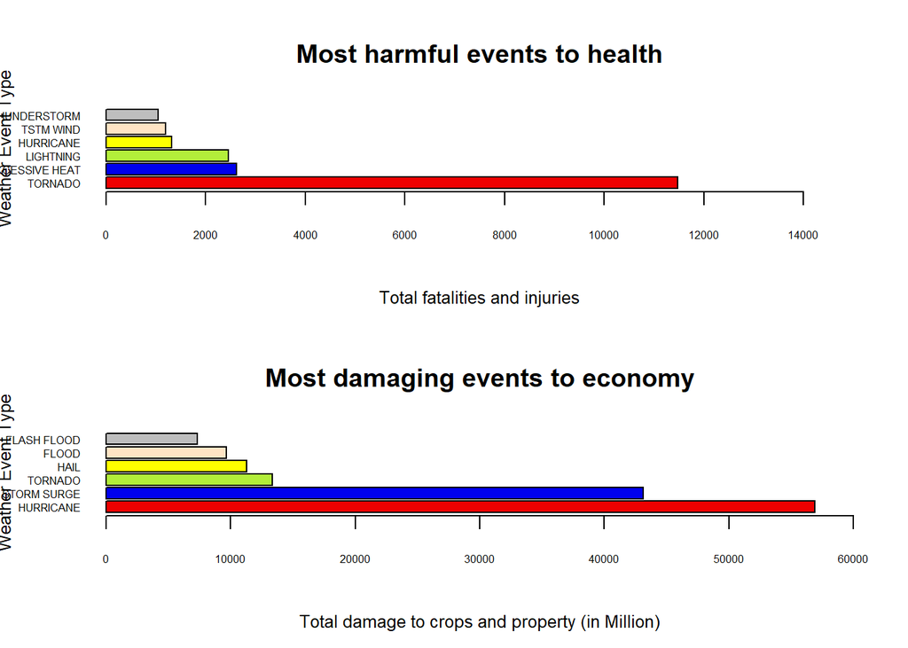

```r
par(mfrow=c(2,1))

setcol <- c("red2","blue2", "olivedrab2", "yellow", "bisque", rep("grey", 1))

barplot(healthEvt$totalHealth[1:6], names=healthEvt$eventType[1:6]
    ,horiz=T, las=1, xlim=c(0,15000), col=setcol
    ,cex.axis=0.5, cex=0.5, cex.lab=0.8, mgp=c(3.5,1,0)
    ,main="Most harmful events to health"
    ,ylab="Weather Event Type", xlab="Total fatalities and injuries")


barplot(ecoDMGEvt$totalDMG[1:6], names=ecoDMGEvt$eventType[1:6]
    ,horiz=T, las=1, xlim=c(0,60000), col=setcol
    ,cex.axis=0.5, cex=0.5, cex.lab=0.8, mgp=c(3.5,1,0)
    ,main="Most damaging events to economy"
    ,ylab="Weather Event Type", xlab="Total damage to crops and property (in Million)")
```

```r
#save figure
dev.copy(png, file = "stormDataAnalysis.png", height = 600, width = 600)
```

```r
dev.off()
```